# READ ME

The following noteboook is built in a sequential manner. All required packages and downloads are in the first cell. Please check its correct execution before running the remaining code.

Code was run on a laptop locally: Ubuntu 22.04.2 LTS 64bit 11th Gen Intel® Core™ i5-1135G7 @ 2.40GHz × 8

Total running time: ~40 seconds (excluding package downloads)

## Libraries and downloads

All pip install packages and downloads are commented.

```python
import pandas as pd
import numpy as np
np.random.seed(30224)

import matplotlib.pyplot as plt
import warnings
warnings.filterwarnings("ignore")
import matplotlib.dates as mdates

import seaborn as sns

from sklearn.feature_extraction.text import TfidfVectorizer

#!pip install nltk
import nltk
from nltk.stem.porter import *

#! pip install wordcloud
# ! pip install --upgrade pip
# ! pip install --upgrade Pillow

import wordcloud
from wordcloud import WordCloud, STOPWORDS, ImageColorGenerator

# ! pip install textblob
import textblob
from textblob import TextBlob

#nltk.download('vader_lexicon')
from nltk.sentiment.vader import SentimentIntensityAnalyzer as SIA

#! pip install spaCy
# ! python3 -m spacy download en_core_web_sm
import spacy

from sklearn.decomposition import TruncatedSVD
```

## Data exploration, clean up and visuzalization

```python
data= pd.read_csv("news_data.csv")
print(data.shape)
data.head()
```

```
(3338, 3)
```

|  | headline | description | date |
| --- | --- | --- | --- |
| 0 | Gaza’s journalists: ‘Targets’ or ‘casual... | Gaza’s journalists are being killed at an u... | 23-12-2023 |
| 1 | Israel orders ‘death corridor’ evacuati... | Hundreds of Palestinians were forced to eva... | 23-12-2023 |
| 2 | Israel’s war on Gaza: List of key events, day 78 | UN Security Council passes resolution ... | 23-12-2023 |
| 3 | US accuses Iran of being ‘deeply involved’... | White House says Tehran is providing Yemeni ... | 23-12-2023 |
| 4 | Israeli forces continue attacks amid crit... | The watered-down resolution boosting aid ... | 23-12-2023 |

```python
data.tail()
```

|  | headline | description | date |
| --- | --- | --- | --- |
| 3333 | In Pictures: Israeli forces storm Al-Aqsa co... | Scores of Palestinians wounded after Isra... | 10-05-2021 |
| 3334 | Why American politicians cannot say the wo... | American political language does not hav... | 09-05-2021 |
| 3335 | Photos: Palestinians vow to save Sheikh Jar... | Palestinians continue solidarity prote... | 05-05-2021 |
| 3336 | The War in June 1967 | The June 1967 Arab-Israeli war lasted only s... | 02-06-2017 |
| 3337 | Photos: Fears over Al-Aqsa stained-glass win... | Israeli raids at the Al-Aqsa Mosque compound... | 03-10-2014 |

```python
# Finding NA headlines
data[data['headline'].isna()==True]
```

|  | headline | description | date |
| --- | --- | --- | --- |

```python
# Finding NA description
data[data['description'].isna()==True]
```

|  | headline | description | date |
| --- | --- | --- | --- |

```python
# Finding NA date
data[data['date'].isna()==True]
```

|  | headline | description | date |
| --- | --- | --- | --- |

```python
# Remove duplicates in the headline column
data=data.drop_duplicates(subset=['headline'],keep='first')
print(data.shape)
```

```
(3331, 3)
```

```python
# Remove duplicates in the description column
data=data.drop_duplicates(subset=['description'],keep='first')
print(data.shape)
```

```
(3330, 3)
```

```python
#combine headline with description into one text column that will be the text data for the analysis onwards
data['merged_text'] = data['headline'] + '. ' + data['description']
# Adding a column with the length of the merged text
data["merged_length"] = data["merged_text"].apply(lambda x: len(str(x)))
df=data[['date','merged_text','merged_length']]
df.head()
```

|  | date | merged_text | merged_length |
| --- | --- | --- | --- |
| 0 | 23-12-2023 | Gaza’s journalists: ‘Targets’ or ‘casual... | 200 |
| 1 | 23-12-2023 | Israel orders ‘death corridor’ evacuati... | 195 |
| 2 | 23-12-2023 | Israel’s war on Gaza: List of key events, day... | 163 |
| 3 | 23-12-2023 | US accuses Iran of being ‘deeply involved’... | 180 |
| 4 | 23-12-2023 | Israeli forces continue attacks amid crit... | 208 |

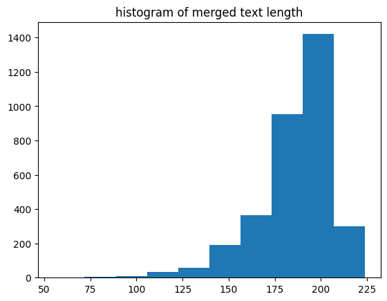

```python
#plot histogram of text lengths
plt.hist(df["merged_length"])
plt.title('histogram of merged text length')
```

```python
#convert date column to date type
df['date'] = pd.to_datetime(df['date'], format='%d-%m-%Y')

#remove all entries before 2021
df=df[df['date'] >= '2021-01-01']

print("start date  ", min(df['date']))
print("end date  ",max(df['date']))
```

```
start date   2021-05-05 00:00:00
end date   2023-12-23 00:00:00
```

## War episodes

We assign an integer value 1-4 corresponding to the 4 respective war intervals explained in the report. A default value of 0 corresponds to a no war date.

```python
#set war label.
#Default no war is zero.
# Define the four specific date intervals
intervals = [(pd.to_datetime('2021-05-01'), pd.to_datetime('2021-05-30')),
             (pd.to_datetime('2022-08-01'), pd.to_datetime('2022-08-30')),
             (pd.to_datetime('2023-05-01'), pd.to_datetime('2023-05-30')),
             (pd.to_datetime('2023-10-07'), pd.to_datetime('2023-12-30'))]

# Initialize the 'condition' column with zeros (no war)
df['war'] = 0
# Assign integer values 1 to 4 based on the date intervals of the 4 respective war intervals
for i, interval in enumerate(intervals, start=1):
    df.loc[(df['date'] >= interval[0]) & (df['date'] < interval[1]), 'war'] = int(i)

# Groupby by WAR
war_df = df.groupby("war")
war_df['war'].count().head()
```

```
war
0    1113
1     182
2      61
3      84
4    1888
Name: war, dtype: int64
```

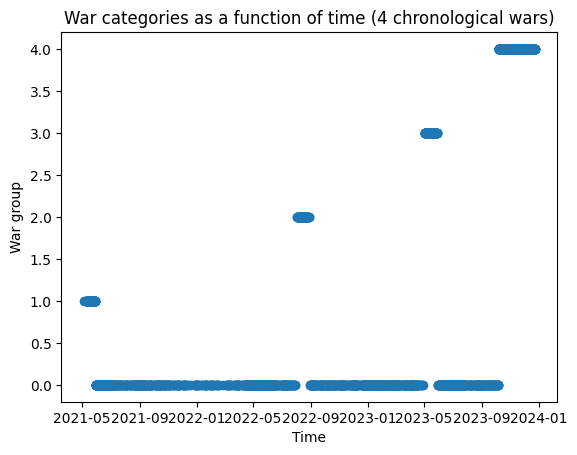

```python
# plot War categories as a function of time in data
plt.scatter(df['date'],df['war'])
plt.title('War categories as a function of time (4 chronological wars)')
plt.ylabel('War group')
plt.xlabel('Time')
```

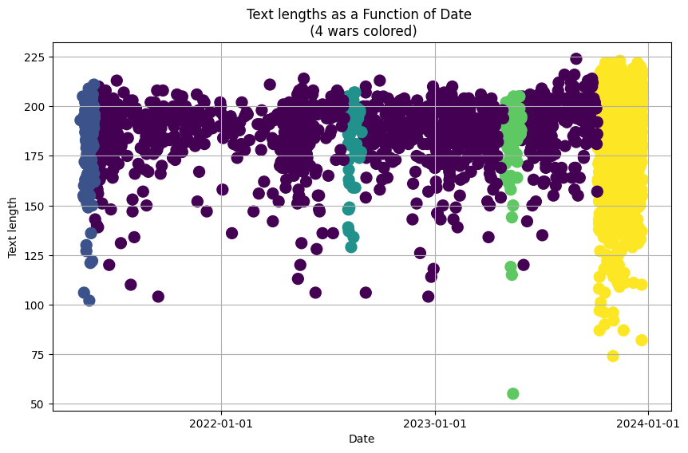

```python
# Scatter plot of text lengths with colored points based on 'war' group
plt.figure(figsize=(10, 6))
plt.scatter(df['date'], df['merged_length'], c=df['war'], cmap='viridis', s=100)
plt.title('Text lengths as a Function of Date \n (4 wars colored)')
plt.xlabel('Date')
plt.ylabel('Text length')
plt.gca().xaxis.set_major_formatter(mdates.DateFormatter('%Y-%m-%d'))  # Format x-axis as date
plt.gca().xaxis.set_major_locator(mdates.YearLocator())  # Set major ticks to be months
plt.grid(True)
plt.show()
```

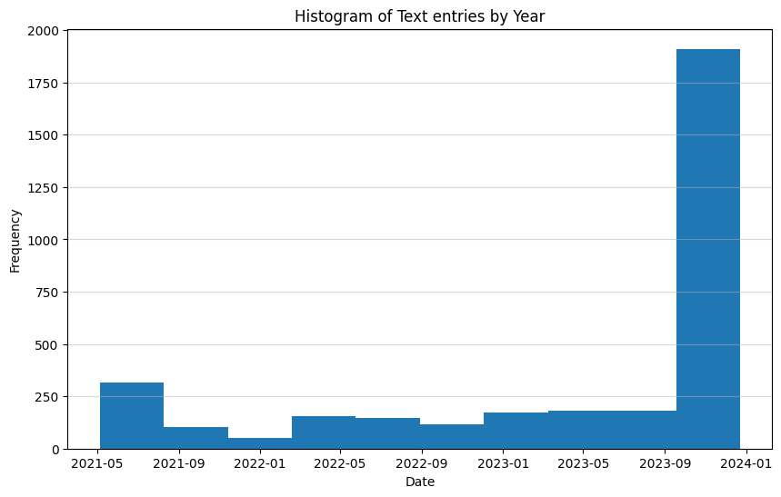

```python
#histogram of data with each year in a bin
plt.figure(figsize=(10, 6))
plt.hist(df['date'])
plt.title('Histogram of Text entries by Year')
plt.xlabel('Date')
plt.ylabel('Frequency')
plt.grid(axis='y', alpha=0.5)
plt.show()
```

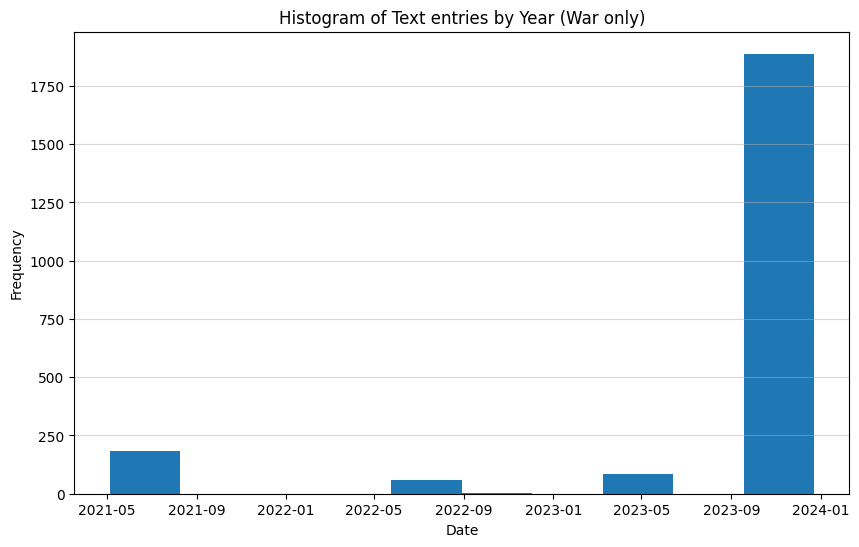

```python
#histogram with each year in a bin for only 'war' entries (war 1-4)
plt.figure(figsize=(10, 6))
plt.hist(df['date'][df['war']!=0] )
plt.title('Histogram of Text entries by Year (War only)')
plt.xlabel('Date')
plt.ylabel('Frequency')
plt.grid(axis='y', alpha=0.5)
plt.show()
```

## Preprocessing

Punctuations and special characters are removed. Lower casing is applied only to words with >3 characters to retain the original casing of accronyms (for visualization purposes).

```python
#Preprocess
# Punctuations and Special Characters are removed
df['text'] = df['merged_text'].str.replace("[^a-zA-Z#]", " ")
df['text'] = df['text'].str.replace('[^\w\s]', '', regex=True)

#lower case only words with more than 3 chars, to keep accronyms upper case
df['text'] = df['text'].apply(lambda x: ' '.join(word.lower() if len(word) > 3 else word for word in x.split()))
df.head()
```

|  | date | merged_text | merged_length | war | text |
| --- | --- | --- | --- | --- | --- |
| 0 | 2023-12-23 | Gaza’s journalists: ‘Targets’ or ‘casual... | 200 | 4 | gazas journalists targets or casualties of isr... |
| 1 | 2023-12-23 | Israel orders ‘death corridor’ evacuati... | 195 | 4 | israel orders death corridor evacuation for pa... |
| 2 | 2023-12-23 | Israel’s war on Gaza: List of key events, day... | 163 | 4 | israels war on gaza list of key events day 78 ... |
| 3 | 2023-12-23 | US accuses Iran of being ‘deeply involved’... | 180 | 4 | US accuses iran of being deeply involved in ho... |
| 4 | 2023-12-23 | Israeli forces continue attacks amid crit... | 208 | 4 | israeli forces continue attacks amid criticism... |

## Corpus specific stopwords extraction

A TF-IDF analysis of the text is conducted.

From its results, a list of relevant words are visually selected as an additional stopwords list to be filtered out from the text, going forward in our analysis.

```python
# Function to compute the TF-IDF of the ratings words, and extract the highest 50 for visual inspection.

def TFIDF_analysis(df,text):
    # Create a TfidfVectorizer, and remove standard english stopwords
    tfidf_vectorizer = TfidfVectorizer(stop_words="english")

    # Fit and transform the 'Review' column
    tfidf_matrix = tfidf_vectorizer.fit_transform(df[text])

    # Get feature names (words) from the TfidfVectorizer
    feature_names = tfidf_vectorizer.get_feature_names_out()

    # Calculate the mean TF-IDF scores for each word across all texts
    mean_tfidf_scores = tfidf_matrix.mean(axis=0).A1

    # Create a DataFrame with words and their mean TF-IDF scores
    tfidf_df = pd.DataFrame({'Word': feature_names, 'Mean_TFIDF': mean_tfidf_scores})

    # Sort the DataFrame by mean TF-IDF scores in descending order
    tfidf_df = tfidf_df.sort_values(by='Mean_TFIDF',ascending=False)

    # Extract the words with the lowest and highest TF-IDF scores
    lowest_tfidf_words = tfidf_df.tail(50)['Word'].to_list()
    highest_tfidf_words = tfidf_df.head(50)['Word'].to_list()
    return(tfidf_df)

tfidf_df= TFIDF_analysis(df,'text')
```

```python
# Top 40 TF-IDF terms
tfidf_df.head(40)
```

|  | Word | Mean_TFIDF |
| --- | --- | --- |
| 3327 | gaza | 0.044267 |
| 4125 | israeli | 0.040367 |
| 4119 | israel | 0.036684 |
| 5360 | palestinian | 0.028352 |
| 5367 | palestinians | 0.026790 |
| 7974 | war | 0.026326 |
| 4322 | killed | 0.020530 |
| 4144 | israels | 0.020222 |
| 6520 | says | 0.017929 |
| 8072 | west | 0.017493 |
| 1072 | bank | 0.016675 |
| 3191 | forces | 0.015349 |
| 3527 | hamas | 0.015293 |
| 5189 | occupied | 0.014446 |
| 952 | attack | 0.013224 |
| 957 | attacks | 0.012238 |
| 4124 | israelhamas | 0.011592 |
| 2122 | day | 0.011352 |
| 3739 | hospital | 0.010956 |
| 5923 | raid | 0.010375 |
| 6518 | say | 0.010343 |
| 5462 | people | 0.009979 |
| 375 | abu | 0.009917 |
| 706 | amid | 0.009909 |
| 5357 | palestine | 0.009771 |
| 4199 | jenin | 0.009349 |
| 1613 | children | 0.008971 |
| 1530 | ceasefire | 0.008950 |
| 565 | al | 0.008931 |
| 7597 | truce | 0.008622 |
| 3332 | gazas | 0.008619 |
| 7793 | updates | 0.008575 |
| 4324 | killing | 0.008573 |
| 2587 | east | 0.007889 |
| 4194 | jazeera | 0.007874 |
| 5507 | photos | 0.007861 |
| 4205 | jerusalem | 0.007796 |
| 5926 | raids | 0.007786 |
| 550 | air | 0.007760 |
| 4817 | military | 0.007487 |

```python
#From that list, we visuall select a subset to curate a custom stop words list
custom_stopwords= [ 'jazeera', 'updates', 'palestine', 'amid',  'people', 'say', 'photo','call', 'day', 'picture','media', 'photos','pictures','picture',
                   'one','two','three', 'continue','calls','least','year','month',
                   'will','says', 'israels', 'palestinians', 'palestinian', 'israel', 'israeli','gaza','gazas',
                   'arab','jewish','muslim']

# Removing common words from our custom stop list
remove_list = custom_stopwords
for word in remove_list:
    df['text'] = df['text'].str.replace(word, " ")

# Removing Short Words with 1 character only
df['text'] = df['text'].apply(lambda x: ' '.join([w for w in x.split() if len(w)>1]))

df.head()
```

|  | date | merged_text | merged_length | war | text |
| --- | --- | --- | --- | --- | --- |
| 0 | 2023-12-23 | Gaza’s journalists: ‘Targets’ or ‘casual... | 200 | 4 | journalists targets or casualties of war journ... |
| 1 | 2023-12-23 | Israel orders ‘death corridor’ evacuati... | 195 | 4 | orders death corridor evacuation for in centra... |
| 2 | 2023-12-23 | Israel’s war on Gaza: List of key events, day... | 163 | 4 | war on list of key events 78 UN security counc... |
| 3 | 2023-12-23 | US accuses Iran of being ‘deeply involved’... | 180 | 4 | US accuses iran of being deeply involved in ho... |
| 4 | 2023-12-23 | Israeli forces continue attacks amid crit... | 208 | 4 | forces attacks criticism over unsc resolution ... |

## Additional preprocessing : Tokenization and Stemming

```python
# Tokenization word based
tokenized_text = df['text'].apply(lambda x: x.split())

#Stem using NLTK porter stemming
stemmer = PorterStemmer()
tokenized_text = tokenized_text.apply(lambda x: [stemmer.stem(i) for i in x])
df['stemmed_text'] = tokenized_text.apply(lambda x: ' '.join(x))

df.head(10)
```

|  | date | merged_text | merged_length | war | text | stemmed_text |
| --- | --- | --- | --- | --- | --- | --- |
| 0 | 2023-12-23 | Gaza’s journalists: ‘Targets’ or ‘casual... | 200 | 4 | journalists targets or casualties of war journ... | journalist target or casualti of war journalis... |
| 1 | 2023-12-23 | Israel orders ‘death corridor’ evacuati... | 195 | 4 | orders death corridor evacuation for in centra... | order death corridor evacu for in central hund... |
| 2 | 2023-12-23 | Israel’s war on Gaza: List of key events, day... | 163 | 4 | war on list of key events 78 UN security counc... | war on list of key event 78 un secur council p... |
| 3 | 2023-12-23 | US accuses Iran of being ‘deeply involved’... | 180 | 4 | US accuses iran of being deeply involved in ho... | us accus iran of be deepli involv in houthi at... |
| 4 | 2023-12-23 | Israeli forces continue attacks amid crit... | 208 | 4 | forces attacks criticism over unsc resolution ... | forc attack critic over unsc resolut on the wa... |
| 5 | 2023-12-22 | RSF files second war crimes complaint with I... | 204 | 4 | RSF files second war crimes complaint with ICC... | rsf file second war crime complaint with icc o... |
| 6 | 2023-12-22 | UN Security Council passes resolution ... | 200 | 4 | UN security council passes resolution on incre... | un secur council pass resolut on increas aid d... |
| 7 | 2023-12-22 | Watching the watchdogs: Why the West misin... | 216 | 4 | watching the watchdogs Why the west misinterpr... | watch the watchdog whi the west misinterpret m... |
| 8 | 2023-12-22 | Marianne Williamson on her US presidentia... | 207 | 4 | marianne iamson on her US presidential campaig... | mariann iamson on her us presidenti campaign t... |
| 9 | 2023-12-22 | Israel’s AI-powered ‘mass assassination ... | 187 | 4 | aipowered mass assassination factory accountab... | aipow mass assassin factori account cant be tr... |

## Wordcloud visualization

To track to the time evolution of language in our corpus, several wordclouds are created: overall data, the yearly evolution from 2021 to 2023, the four different war data, the 'no war' data.

```python
#Using standard NLT english stopwords
stopwords = set(STOPWORDS)
stopwords.update(custom_stopwords)

# Function to plot wordcloud
def plot_wordcloud(text,max_words):
    cloud = WordCloud(width = 800, height = 800,
                background_color ='white',
                stopwords = stopwords,
                max_words=30,
                repeat=True,
                min_font_size = 10,
                normalize_plurals=True,
                min_word_length=1,
                collocations=False,
                random_state=2
                ).generate_from_text(text)

    plt.figure(figsize = (4, 4), facecolor = None)
    plt.imshow(cloud,interpolation="bilinear")
    plt.axis("off")
    plt.tight_layout(pad = 0)
    plt.show()
    return()
```

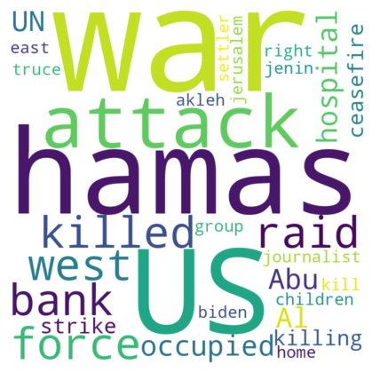

```
()
```

```python
#wordcloud all data combined
text= " ".join(review for review in df['text'])
plot_wordcloud(text,20)
```

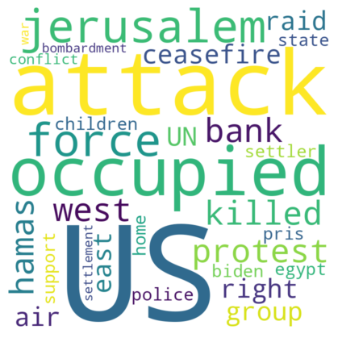

```
()
```

```python
#word cloud year 2021
df_21= df[df['date']< '2022-01-01']
text= " ".join(review for review in df_21['text'])
plot_wordcloud(text,20)
```

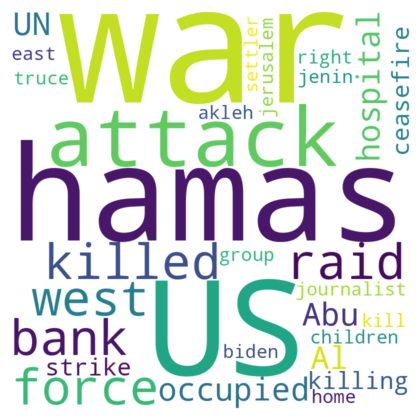

```
()
```

```python
#word cloud year 2022
df_22= df[(df['date'] >= '2022-01-01') | (df['date'] <= '2022-12-31') ]
text= " ".join(review for review in df_22['text'])
plot_wordcloud(text,20)
```

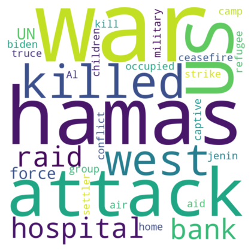

```
()
```

```python
#word cloud year 2023
df_23= df[(df['date'] >= '2023-01-01') ]
text= " ".join(review for review in df_23['text'])
plot_wordcloud(text,20)
```

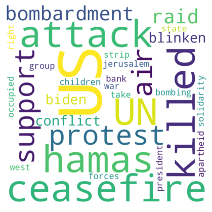

```
()
```

```python
#word cloud war 1
df_1= df[df['war'] ==1]
text= " ".join(review for review in df_1['text'])
plot_wordcloud(text,20)
```

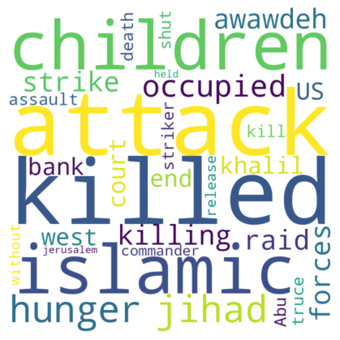

```
()
```

```python
#word cloud war 2
df_2= df[df['war'] ==2]
text= " ".join(review for review in df_2['text'])
plot_wordcloud(text,20)
```

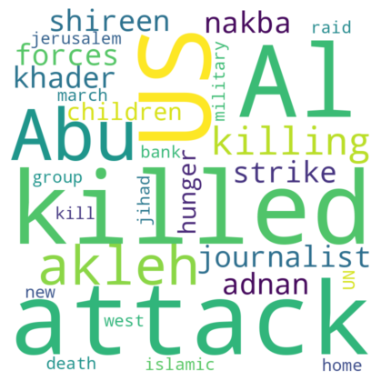

```
()
```

```python
#word cloud war 3
df_3= df[df['war'] ==3]
text= " ".join(review for review in df_3['text'])
plot_wordcloud(text,20)
```

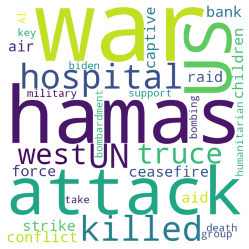

```
()
```

```python
#word cloud war 4
df_4= df[df['war'] ==4]
text= " ".join(review for review in df_4['text'])
plot_wordcloud(text,20)
```

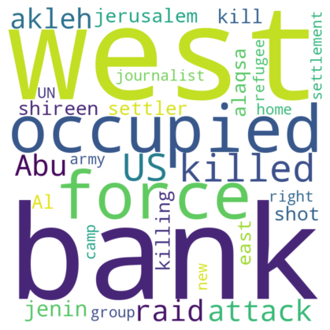

```
()
```

```python
#word cloud no war
df_0= df[df['war'] ==0]
text= " ".join(review for review in df_0['text'])
plot_wordcloud(text,20)
```

## Sentiment analysis: Extracting positive news

The purpose is to attempt to extract positive news among the corpus of news.

As the data is not labeled, this is an unsupervised learning exercise.

We attempt to classify the sentiment using pretrained models (open source), and assess the applicability and results for each model.

Two models pretrained models are used:

1/ Text Blob: trained on twitter posts.

2/ NLTK Vader: trained on reddit news headlines.

### TextBlob

```python
#Determining the Polarity
def sentiment_analyze(text):
    return TextBlob(text).sentiment.polarity

df['sentiment'] = df['stemmed_text'].apply(sentiment_analyze)
```

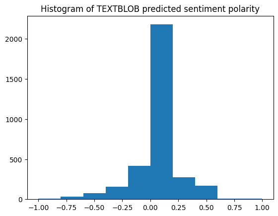

```python
#Plot histogram of predicted sentiment polarity (+1: very positive, -1: very negative)
plt.hist(df['sentiment'])
plt.title('Histogram of TEXTBLOB predicted sentiment polarity')
```

```python
#Visually inspected text assigned a high positive polarity > 0.7
df_positive= df[df['sentiment']>0.7].sort_values('sentiment',ascending=False).head(30)
for i in df_positive['merged_text']:
    print(i,"\n")
```

```
Best of The Take: The life and death of one Palestinian child. We revisit the story of Obaida Jawabra, one of 86 Palestinian children killed in 2021.

What do we know about the Israel-Hamas truce extension?. Hamas and Qatar announce extension of the truce in much-needed respite for people in Gaza braving Israeli bombardment.

Are Biden’s warnings to Israel sparked by fears of 2024 election?. Political scientist Shibley Telhami says Biden is allowing his ‘personal preference’ to drive US policy on Israel.

Hamas deal divides Israel politicians, seen as ‘great harm’, ‘painful’. Israeli PM clinched deal with support of far-right coalition partners, who severely criticised move.

Football ‘can bring joy’ to Lebanon amid Gaza war. Lebanon and Palestine meet in the UAE for a 2026 FIFA World Cup qualifier as war rages in Gaza.

Why China can’t broker peace between Israel and Palestine. Beijing doesn’t have the tools that worked with Iran and Saudi Arabia. But failure could still be a win for China.

Rizwan dedicates Pakistan’s cricket win to ‘brothers and sisters in Gaza’. The Pakistani cricketer has faced backlash for dedicating his team’s Cricket World Cup win to the people of Gaza.

‘Lack of hope’: How will Palestinians vote in Israeli elections?. Al Jazeera looks at the Palestinian parties participating in Israeli elections this year and what residents are saying.

US elections: Bernie Sanders campaigns for Michigan progressives. Left-wing US senator implicitly hits out at the pro-Israel group AIPAC at a rally for Rashida Tlaib and Andy Levin.

US elections: How pro-Israel spending affects Palestine advocacy. Despite massive AIPAC spending in Democratic primaries, advocates say debate over US support for Israel not going away.

Ismail Haniya re-elected as leader of Palestinian group Hamas. Haniya, Hamas chief since 2017, re-elected for four-year term following an unopposed internal election by party members.
```

### NLTK Vader pretrained

Textblob classified most entries in the neutral zone. The result is expected, as it was trained on twitter posts, rather than a news corpus.

We attempst NLTK vader package, guided by :https://www.learndatasci.com/tutorials/sentiment-analysis-reddit-headlines-pythons-nltk/

```python
sia = SIA()
results = []

# Predict polarity of each entry
for line in df['merged_text']:
    pol_score = sia.polarity_scores(line)
    pol_score['headline'] = line
    results.append(pol_score)

df_pol = pd.DataFrame.from_records(results)
df_pol.head()
```

|  | neg | neu | pos | compound | headline |
| --- | --- | --- | --- | --- | --- |
| 0 | 0.164 | 0.836 | 0.000 | -0.6705 | Gaza’s journalists: ‘Targets’ or ‘casual... |
| 1 | 0.111 | 0.889 | 0.000 | -0.4588 | Israel orders ‘death corridor’ evacuati... |
| 2 | 0.127 | 0.784 | 0.088 | -0.2960 | Israel’s war on Gaza: List of key events, day... |
| 3 | 0.153 | 0.847 | 0.000 | -0.5423 | US accuses Iran of being ‘deeply involved’... |
| 4 | 0.000 | 1.000 | 0.000 | 0.0000 | Israeli forces continue attacks amid crit... |

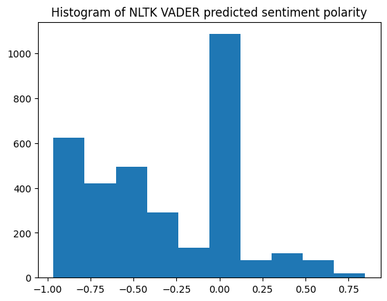

```python
#Plot histogram of predicted sentiment polarity (+1: very positive, -1: very negative)
plt.hist(df_pol['compound'])
plt.title('Histogram of NLTK VADER predicted sentiment polarity')
```

VADER successfully classifies most entries in the negative area, which is a more logical result. Very few entries are positive.

```python
# Add predicted sentiment to our dataframe
df['sentiment']=df_pol['compound']
df.head()
```

|  | date | merged_text | merged_length | war | text | stemmed_text | sentiment |
| --- | --- | --- | --- | --- | --- | --- | --- |
| 0 | 2023-12-23 | Gaza’s journalists: ‘Targets’ or ‘casual... | 200 | 4 | journalists targets or casualties of war journ... | journalist target or casualti of war journalis... | -0.6705 |
| 1 | 2023-12-23 | Israel orders ‘death corridor’ evacuati... | 195 | 4 | orders death corridor evacuation for in centra... | order death corridor evacu for in central hund... | -0.4588 |
| 2 | 2023-12-23 | Israel’s war on Gaza: List of key events, day... | 163 | 4 | war on list of key events 78 UN security counc... | war on list of key event 78 un secur council p... | -0.2960 |
| 3 | 2023-12-23 | US accuses Iran of being ‘deeply involved’... | 180 | 4 | US accuses iran of being deeply involved in ho... | us accus iran of be deepli involv in houthi at... | -0.5423 |
| 4 | 2023-12-23 | Israeli forces continue attacks amid crit... | 208 | 4 | forces attacks criticism over unsc resolution ... | forc attack critic over unsc resolut on the wa... | 0.0000 |

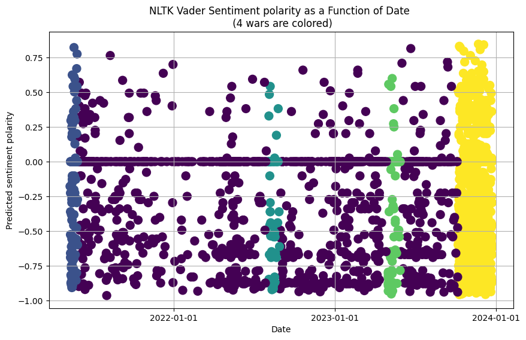

```python
# Scatter plot with colored points based on 'war'
plt.figure(figsize=(10, 6))
plt.scatter(df['date'], df['sentiment'], c=df['war'], cmap='viridis', s=100)
plt.title('NLTK Vader Sentiment polarity as a Function of Date \n (4 wars are colored)')
plt.xlabel('Date')
plt.ylabel('Predicted sentiment polarity')
plt.gca().xaxis.set_major_formatter(mdates.DateFormatter('%Y-%m-%d'))
plt.gca().xaxis.set_major_locator(mdates.YearLocator())
plt.grid(True)
plt.show()
```

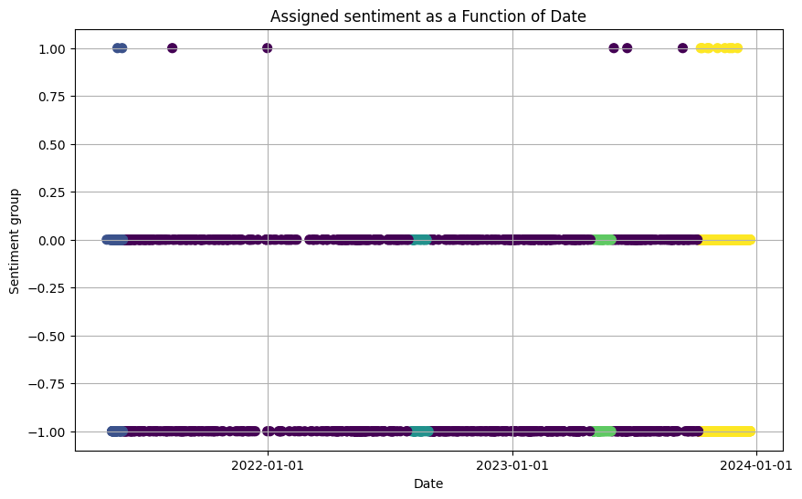

```python
# Assign sentiment labels based on selected thresholds
df['label'] = 0  # Neutral
df.loc[df['sentiment'] > 0.7, 'label'] = 1 # A more strict threshold is set for positive news given the overall negativity in our corpus theme (war)
df.loc[df['sentiment'] < -0.3, 'label'] = -1 #Negative sentiment

# Scatter plot with colored points based on 'war'
plt.figure(figsize=(10, 6))
plt.scatter(df['date'], df['label'], c=df['war'], cmap='viridis', s=50)
plt.title('Assigned sentiment as a Function of Date')
plt.xlabel('Date')
plt.ylabel('Sentiment group')
plt.gca().xaxis.set_major_formatter(mdates.DateFormatter('%Y-%m-%d'))
plt.gca().xaxis.set_major_locator(mdates.YearLocator())
plt.grid(True)
plt.show()
```

```python
# Visually assess the positive entries
df_positive= df[df['sentiment']>0.7].sort_values('sentiment',ascending=False).head(30)
print(len(df_positive))
for i in df_positive['merged_text']:
    print(i,"\n")
```

```
16
Israel-Hamas truce deal: All that you need to know. The two sides have agreed to a four-day pause in fighting, but Israel has made it clear that it is not ending the war.

Finally free, Ubai was among the last Palestinian detainees Israel released. Tired but relieved, he is happy he can resume treatment to save his arm and pursue his dreams for the future again.

How global firms are reacting to the Israel-Hamas conflict. Companies ranging from airlines to banks have shut operations in Israel, asking their employees to work from home.

Under Israeli bombs, Gaza’s Palestinians worry they may die of hunger. ‘Is there enough food for the day? Can we drink or wash? Will we be able to reach our loved ones?’

In Pictures: Celebrations across Gaza after 11 days of bombing. Thousands of Palestinians take to the streets after ceasefire between Israel and Hamas takes effect.

Israeli settlers set up new illegal outpost on Palestinian land. New settler outpost appeared just days after Netanyahu ordered construction of 1,000 new homes in an illegal settlement.

Photos: Tears and joy as second batch of 39 Palestinian prisoners freed. Palestinian prisoners were freed late on Saturday after 13 Israelis were released from Gaza as part of truce agreement.

EU-US summit to stress unity amid Israel-Hamas and Russia-Ukraine wars. President Biden will host EU’s Charles Michel and Ursula von der Leyen as war rages in Gaza and Ukraine.

Profits or Palestine? UAE-Israel deals likely to continue quietly. The UAE has offered to mediate between Israel and Palestine, and behind the scenes are billions in potential deals.

Palestinian journalists claim pressure by PA amid crackdown. Palestinian Authority has cracked down on media since death of activist Nizar Banat in June, rights advocates say.

‘Significant pause’ in Gaza fighting needed to free captives: US official. Biden administration ‘doing everything we possibly can’ to free captives, official quoted as saying.

‘From the river to the sea’ and the decolonisation of our collective future. True freedom can only be achieved by breaking free from settler colonialism and the nation-state.

The American centre’s embrace of the far right fuels Israel’s war machine. Peace will only come to Palestine if American centrists break with the far right and adopt a new approach on Israel.

Growing up Palestinian after the Oslo Accords. On the 30th anniversary of the accords, Al Jazeera spoke to young Palestinians about how their lives have panned out.

Palestinian toddler seriously wounded by Israeli fire. Young boy is in critical condition after being shot in occupied West Bank incident that also injured his father.

A year in, Biden’s Middle East policy brings little change. Despite change in style, Biden administration has largely continued Donald Trump’s policies in key region, analysts say.
```

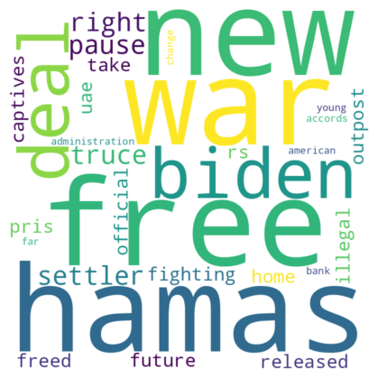

```
()
```

```python
# Wordcloud of the positive entries
text= " ".join(review for review in df_positive['text'])
plot_wordcloud(text,10)
```

```python
#Visually assessing the war labels of positive news
df_positive['war'].head(16)
```

```
636     4
351     4
1815    4
1746    4
3220    1
2069    0
521     4
1510    4
3159    1
3016    0
1107    4
796     4
1456    4
1919    0
2108    0
2888    0
Name: war, dtype: int64
```

```python
# Making a copy of the dataframe for future use in LCA section
df_LCA=df.copy()
```

## NER: persons, organizations and countries

Named Entity Recognition is used to extract names of relevant parties involved in the conflict. SpaCY NER package is used.

```python
# NER: extract names of key players and stakeholders
NER=spacy.load("en_core_web_sm")

#keep only categories: persons, organizations, countries
ner_categories=['PERSON','GPE','ORG','NORP']
```

```python
# function to perform NER on a given text
def perform_ner(text):
    doc = NER(text)
    entities=[]
    labels=[]
    for ent in doc.ents:
        if ent.label_ in ner_categories:
            entities.append((ent.text))
            labels.append((ent.label_))
    return entities

# Apply the function to the 'stemmed_text' column of our DataFrame
df['entities'] = df['stemmed_text'].apply(perform_ner)
```

```python
# Extract the list of entities with their relative frequencies
all_entities = [ent for entities_list in df['entities'] for ent in entities_list]
entity_counts = pd.Series(all_entities).value_counts().reset_index()
entity_counts.columns = ['Entity', 'Frequency']

print(entity_counts.head(30))
```

```
                  Entity  Frequency
0                     un        225
1                     us        186
2                   armi        131
3                   hama        119
4              abu akleh        119
5              west bank        114
6       occupi west bank        103
7              jerusalem        103
8               militari         84
9                lebanon         75
10                 egypt         72
11                    al         71
12  the occupi west bank         63
13        east jerusalem         58
```

[output cut: 16 more lines]

```python
# Print list format for manual manipulation in the next cell
print(list(entity_counts['Entity'].head(40)))
```

```
['un', 'us', 'armi', 'hama', 'abu akleh', 'west bank', 'occupi west bank', 'jerusalem', 'militari', 'lebanon', 'egypt', 'al', 'the occupi west bank', 'east jerusalem', 'hama war', 'hezbollah', 'american', 'nablu', 'washington', 'iran', 'qatar', 'the west bank', 'alshifa hospit', 'russia', 'netanyahu…
```

### Select terms to track time evolution

```python
#Curate list of parties involved: persons and organizations of interest based on NER results above

NER_track= ['un', 'us', 'hama', 'abu akleh', 'west bank',
              'lebanon', 'egypt', 'al',
             'hezbollah', 'american',  'washington', 'iran', 'qatar',
             'russia', 'netanyahu','yemen', 'joe biden', 'abus',
             'syria', 'china',  'jordan']
```

## Time series analysis (aggregated over 1 month periods)

A TF-IDF analysis of the data for each period (1 month) is peformed.

The results are stored as a dictionary where each key corresponds to 1 period, and its value is the TF-IDF results dataframe.

```python
# Break the whole time range into 1 month periods
start_date = df['date'].min() - pd.DateOffset(months=1)
end_date = df['date'].max() + pd.DateOffset(months=1)
date_ranges = pd.date_range(start=start_date, end=end_date, freq='MS')

# Create a dictionary to store results for each month
results_dict = {}
# select words to track time evolution
select_words=NER_track

for i in range(len(date_ranges) - 1):
    start_date = date_ranges[i]
    end_date = date_ranges[i + 1]
    mask = (df['date'] >= start_date) & (df['date'] < end_date)
    monthly_dataframe = df.loc[mask].copy()

    # Compute TF-IDF results of the non-stemmed Tokens for each period
    tfidf_results = TFIDF_analysis(monthly_dataframe,'stemmed_text')
    tfidf_results['rank']= 0

    # Filter out words not in select_words
    if select_words is not None:
        tfidf_results = tfidf_results[tfidf_results['Word'].isin(select_words)].copy()

    # Add rank column of sorted terms
    rank=tfidf_results.rank(method='first')
    tfidf_results['rank']= rank.iloc[:,2]

    results_dict[start_date] = tfidf_results[['Word','rank']]

#print(results_dict)
```

```python
# Merging all dataframes into 1 dataframe for comparison and visualization
merged_df = pd.DataFrame()

for date, df in results_dict.items():
    # Renaming the 'rank' column with the date
    df_time = df.rename(columns={'rank': date})

    # Merging dataframes
    if merged_df.empty:
        merged_df = df_time
    else:
        merged_df = pd.merge(merged_df, df_time, on='Word', how='outer')

print(merged_df)
```

```
          Word  2021-05-01 00:00:00  2021-06-01 00:00:00  2021-07-01 00:00:00  \
0         hama                  1.0                  1.0                  2.0
1    netanyahu                  2.0                  3.0                  NaN
2        egypt                  3.0                  6.0                  NaN
3           al                  4.0                  2.0                  NaN
4     american                  5.0                  NaN                  NaN
5   washington                  6.0                  4.0                  NaN
6         abus                  7.0                  9.0                  3.0
7         iran                  8.0                  8.0                  NaN
8       jordan                  9.0                  NaN                  1.0
9        qatar                 10.0                  NaN                  NaN
10   hezbollah                 11.0                  7.0                  NaN
11     lebanon                 12.0                  NaN                  NaN
12       china                  NaN                  5.0                  NaN
13       syria                  NaN                  NaN                  NaN
```

[output cut: 112 more lines]

```python
# Function to plot the TF-IDF Rank vs time for each term from select list of words
def plot_time_series_word(unique_words):
    plt.figure(figsize=(10, 10))

    for word in unique_words:
        word_data = merged_df[merged_df['Word'] == word]
        plt.scatter(word_data.columns[1:], word_data.iloc[0, 1:], marker='o', label=word, s=300 )

    plt.xlabel('Date')
    plt.ylabel('TF-IDF rank')
    plt.title('TF-IDF word Rank Over Time \n (Rank 1: most important)')
    plt.legend()
    plt.gca().invert_yaxis()
    plt.legend(loc='center left', bbox_to_anchor=(1, 0.5))
    plt.xticks(rotation=45)

    # defining the 4 war intervals
    date_intervals = [
    ('2021-05-01', '2021-05-30'),
    ('2022-08-01', '2022-08-30'),
    ('2023-05-01', '2023-05-30'),
    ('2023-10-07', '2023-12-31')]

    # Highlighting date intervals with vertical strips
    for start_date, end_date in date_intervals:
        plt.axvspan(pd.to_datetime(start_date), pd.to_datetime(end_date), alpha=0.2, color='blue')

    plt.show()
```

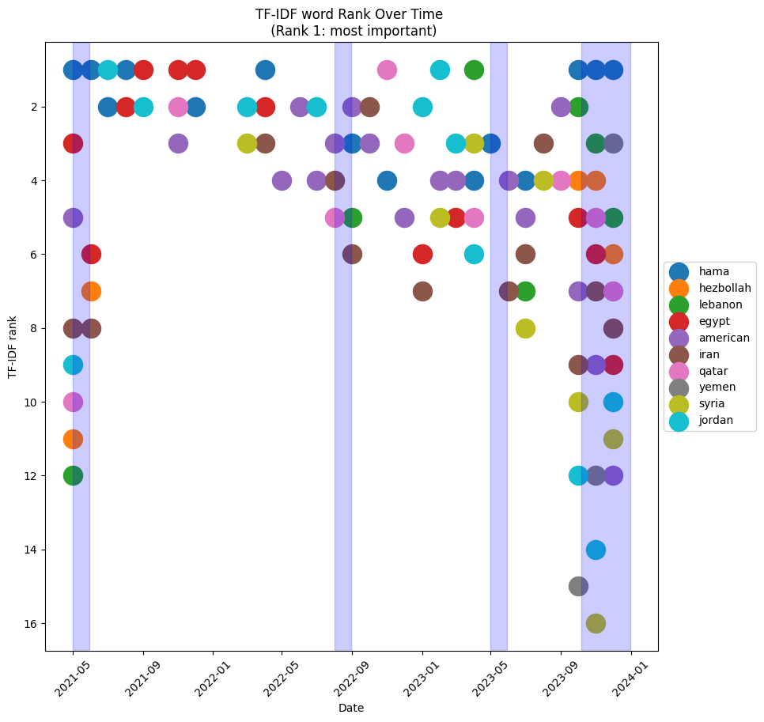

```python
# Lists of interests
countries=  ['lebanon', 'egypt',
             'american',  'iran', 'qatar',
             'yemen',
             'syria',  'jordan']

groups= [ 'hama', 'hezbollah']

unique_words =  (groups + countries)

plot_time_series_word(unique_words)
```

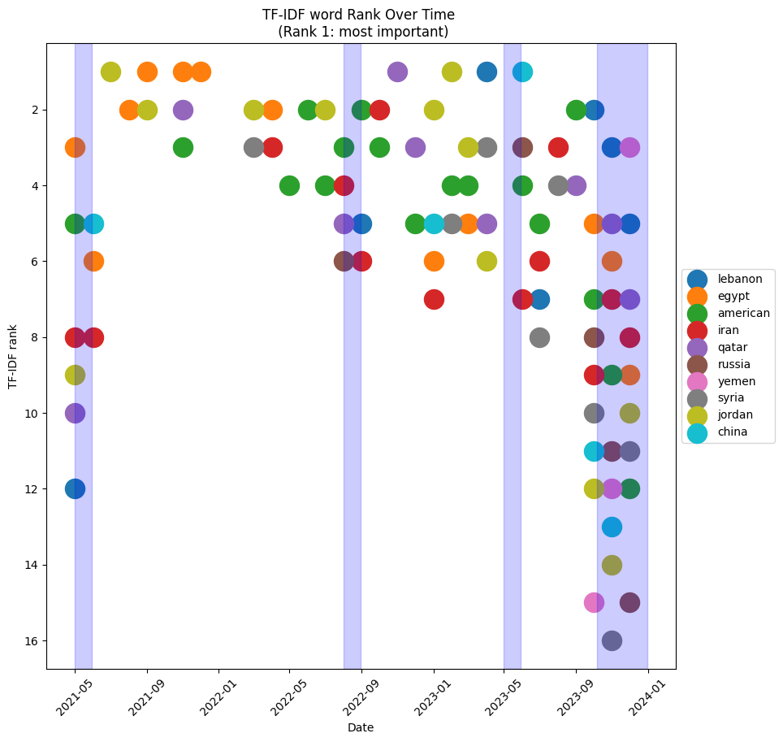

```python
# Select countries comparison
countries_2=  [
              'lebanon', 'egypt',
             'american',  'iran', 'qatar',
             'russia','yemen',
             'syria',  'jordan','china']
plot_time_series_word(countries_2)
```

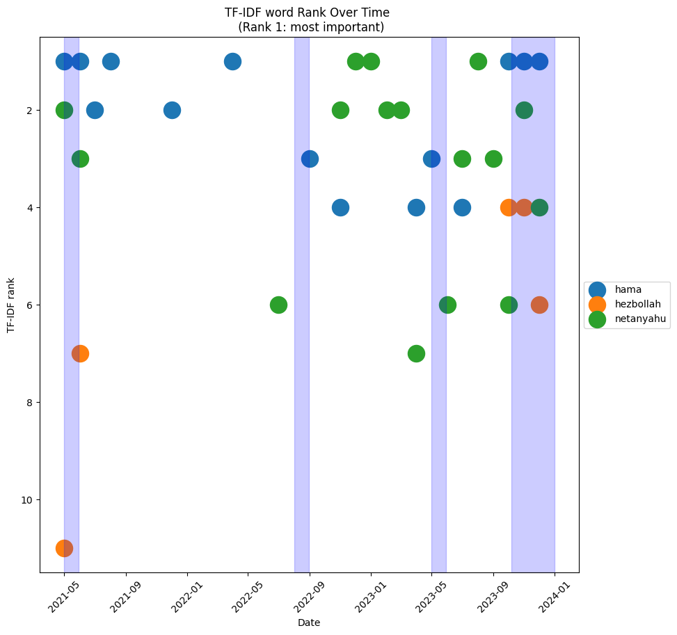

```python
# Groups
groups= [ 'hama', 'hezbollah','netanyahu']
plot_time_series_word(groups)
```

# LCA

LCA is performed in an attempt to extract dominant themes in our data. The preprocessed stemmed text is used.

```python
#LCA object

# Create a matrix representation of the data using TF-IDF vectorization
vectorizer = TfidfVectorizer(min_df=5,stop_words='english', max_features=1000)

#stemmed text used
tfidf_matrix = vectorizer.fit_transform(df_LCA['stemmed_text'])
#tfidf_matrix.todense()
```

```python
#K=2 components
svd = TruncatedSVD(n_components=2)
lsa = svd.fit_transform(tfidf_matrix)
```

```python
# plot document encoding with k=2
topic_encoded_df = pd.DataFrame(lsa, columns = ["topic_1", "topic_2"])
topic_encoded_df["body"] = df_LCA['merged_text']
topic_encoded_df['war']=df_LCA['war']
display(topic_encoded_df[["body", "topic_1", "topic_2"]])
```

|  | body | topic_1 | topic_2 |
| --- | --- | --- | --- |
| 0 | Gaza’s journalists: ‘Targets’ or ‘casual... | 0.157096 | 0.059568 |
| 1 | Israel orders ‘death corridor’ evacuati... | 0.120789 | 0.023222 |
| 2 | Israel’s war on Gaza: List of key events, day... | 0.091692 | 0.284132 |
| 3 | US accuses Iran of being ‘deeply involved’... | 0.068459 | 0.056846 |
| 4 | Israeli forces continue attacks amid crit... | 0.113786 | 0.059171 |
| ... | ... | ... | ... |
| 3323 | Digital apartheid: Palestinians being si... | 0.164480 | 0.006694 |
| 3324 | Jerusalem: ‘She is 12 years old, yet they have... | 0.294916 | 0.058337 |
| 3325 | In Pictures: Ruins and devastation as Is... | 0.161737 | -0.022998 |
| 3326 | Know their names: Palestinian children kill... | 0.030735 | 0.042455 |
| 3327 | ‘The Skunk’: Another Israeli weapon for col... | 0.163178 | -0.022966 |

3328 rows × 3 columns

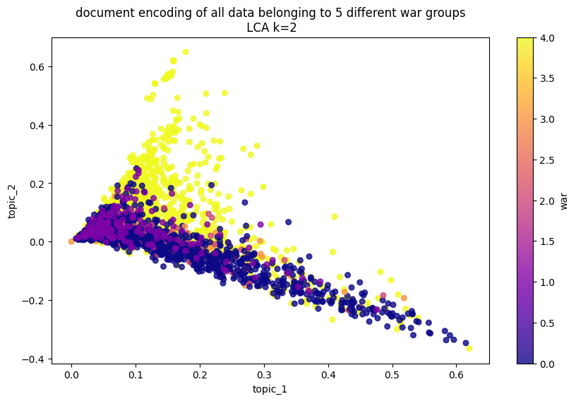

```python
# document encoding belonging to 4 different war groups
plt.figure(figsize=(10, 6))
plt.scatter(topic_encoded_df["topic_1"],topic_encoded_df["topic_2"], c=topic_encoded_df['war'], cmap='plasma', s=30,alpha=0.8)
plt.colorbar(label='war')
plt.xlabel('topic_1')
plt.ylabel('topic_2')
plt.title('document encoding of all data belonging to 5 different war groups\n LCA k=2')
```

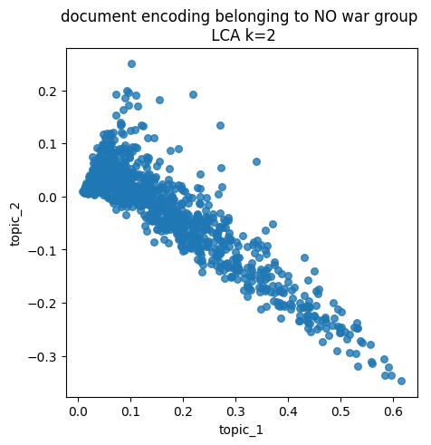

```python
# document encoding belonging to no war group
df_plt=topic_encoded_df[topic_encoded_df['war']==0]
plt.figure(figsize=(5, 5))
plt.scatter(df_plt["topic_1"],df_plt["topic_2"], s=30,alpha=0.8)
plt.xlabel('topic_1')
plt.ylabel('topic_2')
plt.title('document encoding belonging to NO war group \n LCA k=2')
```

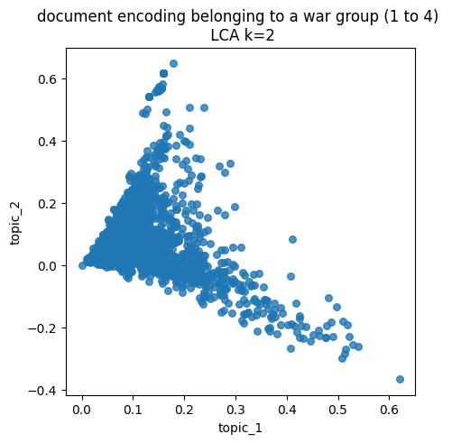

```python
# document encoding belonging all war groups (1 to 4)
df_plt=topic_encoded_df[topic_encoded_df['war']!=0]
plt.figure(figsize=(5, 5))
plt.scatter(df_plt["topic_1"],df_plt["topic_2"], s=30,alpha=0.8)
plt.xlabel('topic_1')
plt.ylabel('topic_2')
plt.title('document encoding belonging to a war group (1 to 4) \n LCA k=2')
```

It appears the documents belonging to one of 4 war episodes tend to have positive topic 2 values (and low topic 1 values).

We speculate topic 2 might refer to language of 'active war', as in not just a conflict happening in the background, but active deployment of resources to fight.

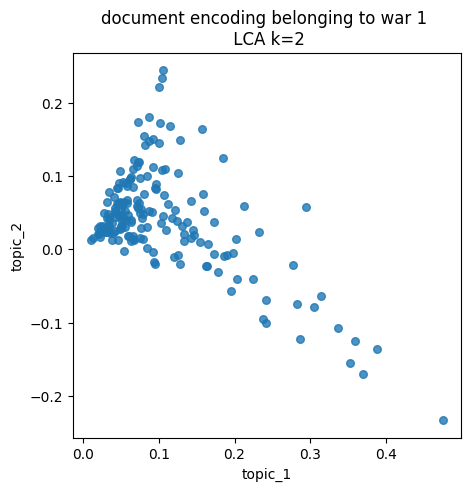

```python
# document encoding belonging to war 1
df_plt=topic_encoded_df[topic_encoded_df['war']==1]
plt.figure(figsize=(5,5))
plt.scatter(df_plt["topic_1"],df_plt["topic_2"], s=30,alpha=0.8)
plt.xlabel('topic_1')
plt.ylabel('topic_2')
plt.title('document encoding belonging to war 1 \n LCA k=2')
```

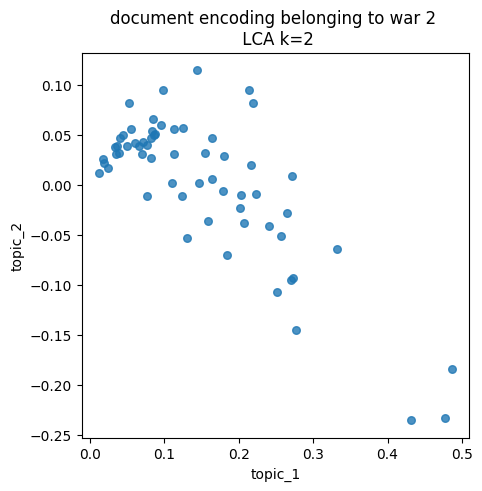

```python
# document encoding belonging to war 2
df_plt=topic_encoded_df[topic_encoded_df['war']==2]
plt.figure(figsize=(5,5))
plt.scatter(df_plt["topic_1"],df_plt["topic_2"], s=30,alpha=0.8)
plt.xlabel('topic_1')
plt.ylabel('topic_2')
plt.title('document encoding belonging to war 2 \n LCA k=2')
```

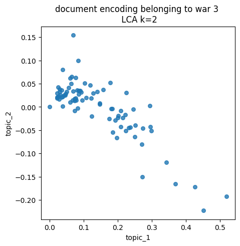

```python
# document encoding belonging to war 3
df_plt=topic_encoded_df[topic_encoded_df['war']==3]
plt.figure(figsize=(5,5))
plt.scatter(df_plt["topic_1"],df_plt["topic_2"], s=30,alpha=0.8)
plt.xlabel('topic_1')
plt.ylabel('topic_2')
plt.title('document encoding belonging to war 3 \n LCA k=2')
```

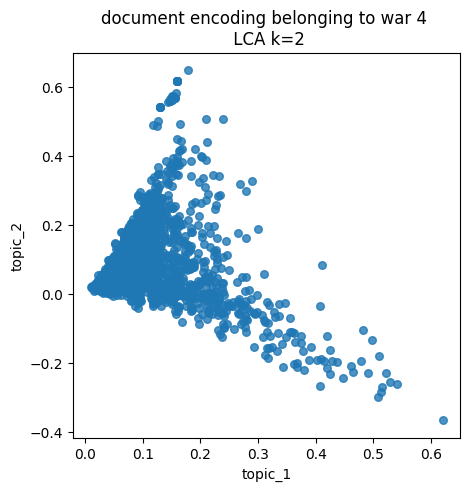

```python
# document encoding belonging to war 4
df_plt=topic_encoded_df[topic_encoded_df['war']==4]
plt.figure(figsize=(5,5))
plt.scatter(df_plt["topic_1"],df_plt["topic_2"], s=30,alpha=0.8)
plt.xlabel('topic_1')
plt.ylabel('topic_2')
plt.title('document encoding belonging to war 4 \n LCA k=2')
```

```python
# summary statistic of topic 1 weights
topic_encoded_df["topic_1"].describe()
```

```
count    3328.000000
mean        0.128434
std         0.102326
min         0.000000
25%         0.057944
50%         0.093091
75%         0.163151
max         0.620169
Name: topic_1, dtype: float64
```

```python
# summary statistic of topic 2 weights
topic_encoded_df["topic_2"].describe()
```

```
count    3328.000000
mean        0.048004
std         0.118457
min        -0.365716
25%         0.001590
50%         0.040231
75%         0.095384
max         0.649197
Name: topic_2, dtype: float64
```

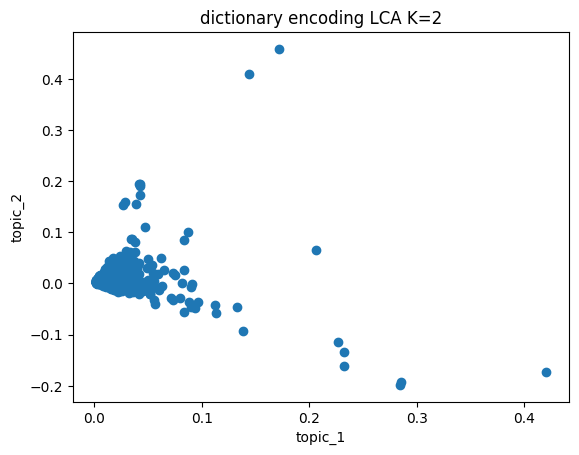

```python
#Extract dictionary from Vectorization
dictionary = vectorizer.get_feature_names_out()
#Show topic weights for dictionary words
encoding_matrix = pd.DataFrame(svd.components_,
                               index=['topic_1', 'topic_2']).T
encoding_matrix["terms"] = dictionary

plt.scatter(encoding_matrix["topic_1"],encoding_matrix["topic_2"])
plt.xlabel('topic_1')
plt.ylabel('topic_2')
plt.title('dictionary encoding LCA K=2')
```

```python
# Sort dictionary by topic 1
sorted_df = encoding_matrix.sort_values(by='topic_1', ascending=False)

# Show top dictionary words for topic 1
display(sorted_df.head(20))
```

|  | topic_1 | topic_2 | terms |
| --- | --- | --- | --- |
| 509 | 0.420921 | -0.172597 | kill |
| 978 | 0.285897 | -0.193506 | west |
| 105 | 0.284803 | -0.198073 | bank |
| 620 | 0.232090 | -0.160845 | occupi |
| 709 | 0.232014 | -0.134751 | raid |
| 382 | 0.226620 | -0.113925 | forc |
| 94 | 0.206122 | 0.064680 | attack |
| 967 | 0.172368 | 0.458860 | war |
| 417 | 0.143864 | 0.409746 | hama |
| 493 | 0.138380 | -0.093039 | jenin |
| 965 | 0.132360 | -0.046152 | wa |
| 152 | 0.113192 | -0.058496 | camp |
| 25 | 0.112358 | -0.042662 | abu |
| 55 | 0.096889 | -0.037068 | akleh |
| 805 | 0.094083 | -0.047537 | settler |
| 501 | 0.091248 | -0.000269 | journalist |
| 56 | 0.090369 | -0.007113 | al |
| 730 | 0.090011 | -0.046231 | refuge |
| 87 | 0.087775 | -0.036912 | armi |
| 414 | 0.086840 | 0.099721 | ha |

```python
# Show lowest dictionary words for topic 1
display(sorted_df.tail(20))
```

|  | topic_1 | topic_2 | terms |
| --- | --- | --- | --- |
| 662 | 0.002015 | 0.006019 | platform |
| 719 | 0.002014 | 0.002671 | realiti |
| 434 | 0.001996 | 0.002330 | herzog |
| 926 | 0.001991 | 0.003015 | trial |
| 114 | 0.001985 | 0.006323 | beij |
| 219 | 0.001983 | 0.003514 | content |
| 931 | 0.001956 | 0.003166 | trump |
| 168 | 0.001955 | 0.003669 | censor |
| 496 | 0.001924 | 0.002516 | jew |
| 631 | 0.001902 | 0.004415 | onlin |
| 362 | 0.001889 | 0.004413 | favour |
| 352 | 0.001853 | 0.002628 | facebook |
| 917 | 0.001777 | 0.000679 | tortur |
| 760 | 0.001728 | 0.002597 | revok |
| 318 | 0.001723 | 0.004004 | elsisi |
| 330 | 0.001654 | 0.002793 | ethnic |
| 188 | 0.001654 | 0.002793 | cleans |
| 640 | 0.001617 | 0.001564 | oslo |
| 741 | 0.001614 | 0.003523 | remark |
| 422 | 0.001169 | 0.002825 | harvard |